# Lung_Cancer_Project

## 4 Dotplot of Gene Expression across the cell-types

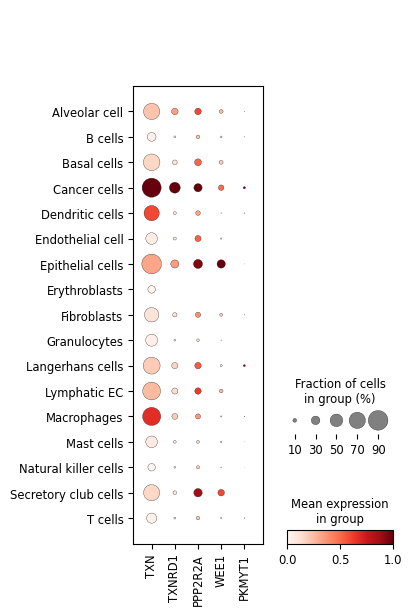

## 5 Summary statistics

Scanpy’s Wilcoxon Rank-Sum Test Between Cancer Cells and Each Other Immune Cell for the DNA Repair Genes:

For the vast majority of cases, each gene’s expression in non-cancer immune cell-types is lower when compared to their expression in the cancer cell. In this Wilcoxon rank sum test (Scanpy has a built in function, rank_genes_groups to compute this), the cancer cells are the reference group. This means that negative log-fold changes represent a decreased expression in the test group (each non-cancer immune celltype), whereas a positive log-fold change would indicate the inverse.

```python
import pandas as pd
pd.set_option("display.max_rows", None)
df = pd.read_csv("~/USF_Lung_Cancer/data/junrang/wilcoxon_degs.csv")
print(df.to_markdown(index = False))
```

```
| names   |     scores |   logfoldchanges |        pvals |    pvals_adj | tested_group         |
|:--------|-----------:|-----------------:|-------------:|-------------:|:---------------------|
| PKMYT1  |  -4.17782  |      -2.75337    | 2.94312e-05  | 9.54067e-05  | Macrophages          |
| PPP2R2A | -14.5934   |      -1.1909     | 3.0949e-48   | 3.71339e-47  | Macrophages          |
| WEE1    | -15.5158   |      -3.14362    | 2.7137e-54   | 3.54686e-53  | Macrophages          |
| TXNRD1  | -28.2883   |      -2.19477    | 4.8131e-176  | 1.68406e-174 | Macrophages          |
| TXN     | -38.7923   |      -1.099      | 0            | 0            | Macrophages          |
| PKMYT1  |  -0.174799 |       0.130905   | 0.861237     | 1            | Langerhans cells     |
| PPP2R2A |  -3.45642  |      -0.634474   | 0.000547405  | 0.00351015   | Langerhans cells     |
| WEE1    |  -5.33524  |      -1.97129    | 9.54182e-08  | 1.01995e-06  | Langerhans cells     |
| TXNRD1  | -11.1852   |      -2.11057    | 4.817e-29    | 1.60564e-27  | Langerhans cells     |
| TXN     | -28.2247   |      -2.36923    | 2.91296e-175 | 8.99146e-173 | Langerhans cells     |
| PKMYT1  |  -1.53085  |      -2.42795    | 0.125806     | 0.369593     | Dendritic cells      |
| PPP2R2A |  -5.65139  |      -0.979348   | 1.59157e-08  | 2.00127e-07  | Dendritic cells      |
| WEE1    |  -6.30472  |      -4.11489    | 2.88716e-10  | 4.31695e-09  | Dendritic cells      |
| TXNRD1  | -13.7566   |      -3.14027    | 4.64732e-43  | 3.61097e-41  | Dendritic cells      |
| TXN     | -18.2055   |      -1.75787    | 4.67056e-74  | 8.09552e-72  | Dendritic cells      |
| PKMYT1  |  -1.70887  |     -25.1713     | 0.0874755    | 0.242208     | Granulocytes         |
| WEE1    |  -5.7124   |      -3.69403    | 1.11395e-08  | 1.04804e-07  | Granulocytes         |
| PPP2R2A |  -7.60667  |      -1.61168    | 2.81254e-14  | 4.67712e-13  | Granulocytes         |
| TXNRD1  | -13.3943   |      -3.46924    | 6.52804e-41  | 5.00327e-39  | Granulocytes         |
| TXN     | -25.0044   |      -3.00754    | 5.46931e-138 | 3.42333e-135 | Granulocytes         |
| PKMYT1  |  -2.43811  |      -2.49313    | 0.0147644    | 0.0516994    | Fibroblasts          |
| WEE1    |  -5.42966  |      -0.752771   | 5.646e-08    | 4.66183e-07  | Fibroblasts          |
| PPP2R2A |  -7.29818  |      -0.812329   | 2.91692e-13  | 3.82134e-12  | Fibroblasts          |
| TXNRD1  | -18.2096   |      -2.48907    | 4.33123e-74  | 3.37701e-72  | Fibroblasts          |
| TXN     | -39.7326   |      -2.67185    | 0            | 0            | Fibroblasts          |
| PKMYT1  |  -4.6076   |      -1.30176    | 4.07339e-06  | 1.01365e-05  | T cells              |
| WEE1    | -18.4263   |      -1.98336    | 8.0757e-76   | 7.1529e-75   | T cells              |
| PPP2R2A | -22.5529   |      -0.878968   | 1.25796e-112 | 1.64132e-111 | T cells              |
| TXNRD1  | -46.9416   |      -3.388      | 0            | 0            | T cells              |
| TXN     | -89.3347   |      -3.28426    | 0            | 0            | T cells              |
| PKMYT1  |  -2.85693  |     -25.1713     | 0.00427756   | 0.0138268    | Endothelial cell     |
| PPP2R2A |  -4.03745  |      -0.00906797 | 5.4036e-05   | 0.000230381  | Endothelial cell     |
| WEE1    |  -8.47232  |      -2.28403    | 2.4056e-17   | 2.70217e-16  | Endothelial cell     |
| TXNRD1  | -20.6497   |      -2.9538     | 9.82272e-95  | 7.90483e-93  | Endothelial cell     |
| TXN     | -41.6613   |      -3.1098     | 0            | 0            | Endothelial cell     |
| PKMYT1  |  -3.63752  |      -3.27455    | 0.000275278  | 0.000733889  | B cells              |
| WEE1    | -11.282    |      -1.31079    | 1.61051e-29  | 1.1572e-28   | B cells              |
| PPP2R2A | -16.0141   |      -1.2552     | 1.01906e-57  | 1.33503e-56  | B cells              |
```

[output cut: 27 more lines]

```
| PKMYT1  |  -0.662589 |     -25.1713     | 0.507594     | 1            | Basal cells          |
| PPP2R2A |  -0.740738 |      -0.170711   | 0.458852     | 1            | Basal cells          |
| WEE1    |  -0.872676 |      -0.899026   | 0.38284      | 1            | Basal cells          |
| TXNRD1  |  -4.21412  |      -2.46759    | 2.50753e-05  | 0.00201075   | Basal cells          |
| TXN     |  -8.47524  |      -2.04409    | 2.34587e-17  | 1.39104e-14  | Basal cells          |
| WEE1    |   1.03168  |       0.479937   | 0.302221     | 1            | Secretory club cells |
| PPP2R2A |   0.131945 |      -0.145074   | 0.895028     | 1            | Secretory club cells |
| PKMYT1  |  -0.929445 |     -25.1713     | 0.352658     | 1            | Secretory club cells |
| TXNRD1  |  -6.54882  |      -3.04658    | 5.79946e-11  | 6.46927e-09  | Secretory club cells |
| TXN     | -13.8242   |      -2.68769    | 1.82032e-43  | 1.7526e-40   | Secretory club cells |
| WEE1    |   4.65606  |       1.31132    | 3.22317e-06  | 4.05742e-05  | Epithelial cells     |
| PPP2R2A |   1.68561  |       0.224798   | 0.0918709    | 0.374544     | Epithelial cells     |
| PKMYT1  |  -1.44864  |      -4.2343     | 0.147439     | 0.539327     | Epithelial cells     |
| TXNRD1  |  -5.16025  |      -1.07933    | 2.46624e-07  | 3.59688e-06  | Epithelial cells     |
| TXN     | -13.9242   |      -0.975521   | 4.51853e-44  | 5.35874e-42  | Epithelial cells     |
```